# EP07-Estadistica

Equipo 1

09-05-2026

# Contexto

En el trabajo de título de una estudiante del DIINF se reportan tiempos de ejecución (en milisegundos) y la cercanía con la solución óptima (en por ciento) de la mejor solución encontrada con tres versiones de un algoritmo genético para resolver instancias del problema del vendedor viajero disponibles en repositorios públicos. Ahora debe enfrentar el análisis de estos datos, por lo que está solicitando ayuda de las y los estudiantes de Estadística Inferencial.

## Lectura de datos

```r
datos_algoritmo <- read.csv("EP07 Datos.csv")

head(datos_algoritmo)
```

|  | instancia | n.nodos | n.aristas | tiempo.A | tiempo.B | tiempo.C | mejor.A | mejor.B | mejor.C |
| --- | --- | --- | --- | --- | --- | --- | --- | --- | --- |
| 1 | 1 | 50 | 631 | 107534 | 452595 | 257485 | 98.72 | 98.25 | 99.34 |
| 2 | 2 | 50 | 521 | 74808 | 364061 | 207297 | 98.99 | 99.17 | 99.48 |
| 3 | 3 | 50 | 588 | 94072 | 417798 | 237793 | 99.10 | 99.23 | 99.10 |
| 4 | 4 | 50 | 653 | 114830 | 470701 | 267598 | 98.69 | 99.23 | 97.82 |
| 5 | 5 | 50 | 597 | 96720 | 425233 | 241770 | 99.80 | 99.22 | 98.14 |
| 6 | 6 | 50 | 564 | 86688 | 398448 | 226833 | 99.19 | 99.15 | 98.04 |

## Descripción de las variables

```r
library(knitr)
library(kableExtra)

# Crear el data frame con la información técnica
tabla_variables <- data.frame(
  Variable = c(
    "instancia",
    "n.nodos",
    "n.aristas",
    "tiempo.A / B / C",
    "mejor.A / B / C",
    "Algoritmo"
  ),
  Clasificación = c(
    "Independiente (ID)",
    "Independiente (Control)",
    "Independiente (Control)",
    "Dependiente (Numérica)",
    "Dependiente (Desempeño)",
    "Factor (Independiente)"
  ),
  Descripción = c(
    "Corresponde a las observaciones. En este caso son instancias del problema del vendedor viajero",
    "Variable cuantitativa que indica el tamaño del grafo",
    "Variable cuantitativa que indica la cantidad de aristas del grafo",
    "Tiempo de ejecución (en milisegundos) que tarda cada algoritmo genético en resolver instancias del problema del vendedor viajero",
    "Porcentaje de cercanía a la solución óptima de la mejor solución encontrada",
    "Tipo de algoritmo utilizado (A, B o C). Actúa como factor con 3 niveles"
  )
)

# Generar la tabla con kableExtra para R Markdown
tabla_variables %>%
  kbl(caption = "Identificación y Clasificación de Variables del Dataset",
      booktabs = TRUE,
      align = "l",
      escape = FALSE) %>% # escape = FALSE permite usar negritas en Markdown
  kable_styling(bootstrap_options = c("striped", "hover", "condensed"),
                full_width = F,
                position = "center") %>%
  column_spec(1, bold = TRUE, border_right = TRUE) %>%
  column_spec(2, italic = TRUE) %>%
  row_spec(0, bold = TRUE, color = "white", background = "#4E79A7") # Encabezado con color
```

Identificación y Clasificación de Variables del Dataset

| Variable | Clasificación | Descripción |
| --- | --- | --- |
| instancia | Independiente (ID) | Corresponde a las observaciones. En este caso son instancias del problema del vendedor viajero |
| n.nodos | Independiente (Control) | Variable cuantitativa que indica el tamaño del grafo |
| n.aristas | Independiente (Control) | Variable cuantitativa que indica la cantidad de aristas del grafo |
| tiempo.A / B / C | Dependiente (Numérica) | Tiempo de ejecución (en milisegundos) que tarda cada algoritmo genético en resolver instancias del problema del vendedor viajero |
| mejor.A / B / C | Dependiente (Desempeño) | Porcentaje de cercanía a la solución óptima de la mejor solución encontrada |
| Algoritmo | Factor (Independiente) | Tipo de algoritmo utilizado (A, B o C). Actúa como factor con 3 niveles |

## Transformar datos

```r
# Pivoteo múltiple: manejamos tiempo y mejor desempeño a la vez
datos_largos <- datos_algoritmo %>%
  pivot_longer(
    cols = c(starts_with("tiempo."), starts_with("mejor.")),
    names_to = c(".value", "Version_alg"),
    names_sep = "\\."
  ) %>%
  mutate(Version_alg = as.factor(Version_alg))

# El resultado tendrá columnas: instancia, n.nodos, n.aristas, Algoritmo, tiempo, mejor
head(datos_largos)
```

| instancia | n.nodos | n.aristas | Version_alg | tiempo | mejor |
| --- | --- | --- | --- | --- | --- |
| 1 | 50 | 631 | A | 107534 | 98.72 |
| 1 | 50 | 631 | B | 452595 | 98.25 |
| 1 | 50 | 631 | C | 257485 | 99.34 |
| 2 | 50 | 521 | A | 74808 | 98.99 |
| 2 | 50 | 521 | B | 364061 | 99.17 |
| 2 | 50 | 521 | C | 207297 | 99.48 |

# Problema 1

Observando los datos, la memorista sospecha que hay diferencias significativas en el tiempo de ejecución entre las versiones A y B del algoritmo cuando las instancias tienen 70 o más nodos. ¿Los datos respaldan la intuición de la memorista? Para responder, filtren los datos para tener las instancias con 70 o más nodos y seleccionen las columnas de los tiempos de ejecución de las versiones A y B (en formato ancho). Usando como semilla el valor 73, obtengan muestras aleatorias independientes de 24 tiempos registrados por la versión A y 20 tiempos registrados por la versión B del algoritmo. Realicen un análisis estadístico pertinente (enunciar hipótesis, revisar condiciones, seleccionar pruebas ómnibus y post-hoc según corresponda) para responder la pregunta planteada, utilizando pruebas no paramétricas de ser necesario.

# Respuesta 1

Filtrado de datos:

```r
library(dplyr)

# Fijar semilla para reproducibilidad
set.seed(73)

# Filtrar instancias y seleccionar columnas en formato ancho
datos_filtrados_pregunta_1 <- datos_algoritmo %>%
  filter(n.nodos >= 70) %>%
  select(tiempo.A, tiempo.B)

# Obtener muestras aleatorias independientes
muestra_A_P1 <- sample(datos_filtrados_pregunta_1$tiempo.A, 24)
muestra_B_P1 <- sample(datos_filtrados_pregunta_1$tiempo.B, 20)
```

Mostrar tabla con las muestras:

```r
library(knitr)
library(kableExtra)

# Como tienen tamaños distintos, creamos una lista o un data frame con NAs para visualización
max_n <- max(length(muestra_A_P1), length(muestra_B_P1))
tabla_muestras_P1 <- data.frame(
  `Tiempo Algoritmo A` = c(muestra_A_P1, rep(NA, max_n - length(muestra_A_P1))),
  `Tiempo Algoritmo B` = c(muestra_B_P1, rep(NA, max_n - length(muestra_B_P1)))
)

# Generar la tabla
tabla_muestras_P1 %>%
  kbl(caption = "Muestras Aleatorias Independientes de Tiempos de Ejecución",
      booktabs = TRUE,
      align = "c") %>%
  kable_styling(bootstrap_options = c("striped", "hover", "condensed"),
                full_width = F) %>%
  add_header_above(c("Versión A (n=24)" = 1, "Versión B (n=20)" = 1))
```

Muestras Aleatorias Independientes de Tiempos de Ejecución

| Versión A (n=24) Tiempo.Algoritmo.A | Versión B (n=20) Tiempo.Algoritmo.B |
| --- | --- |
| 1787996 | 1369662 |
| 1773924 | 3269943 |
| 2318669 | 2630575 |
| 2863814 | 3404616 |
| 454851 | 855320 |
| 984006 | 1727670 |
| 313221 | 3155503 |
| 334128 | 2918597 |
| 2353874 | 1965678 |
| 3484273 | 1406599 |
| 2052909 | 1696931 |
| 589858 | 2029282 |
| 467360 | 1911543 |
| 5598163 | 1348357 |
| 866889 | 1088460 |
| 1745691 | 1992182 |
| 319406 | 1850743 |
| 2176449 | 1048648 |
| 408354 | 1357717 |
| 479164 | 2898259 |
| 382143 | NA |
| 2586617 | NA |
| 1166026 | NA |
| 1176876 | NA |

## Condiciones paramétricas

Las dos muestras capturadas son independientes entre sí, debido a que la elección de los datos se hizo de manera aleatoria y de forma separada para los tiempos de ejecución de las versiones A y B del algoritmo. Además, debemos agregar que los tamaños de las muestras son distintos, por lo que aseguramos que no existe relación alguna entre las observaciones.

La prueba paramétrica apropiada para este problema, es la prueba t de student para dos muestras independientes. Para su aplicación requiere las siguientes condiciones:

1. Cada muestra cumple las condiciones para usar la distribución t.
2. Las muestras son independientes entre sí.

La segunda condición ya fue argumentada, por lo que pasamos a recordar las condiciones para la prueba t de una muestra:

1. Las observaciones son independientes entre sí.
2. Las observaciones provienen de una distribución cercana a la normal.

La función “sample” de R base, permite obtener muestras aleatorias asegurando que las observaciones sean independientes entre sí, ya que no existen sesgos en un algoritmo (sólo opera sobre valores numéricos), a diferencia de lo que podría ocurrir con datos obtenidos de encuestas o seleccionados por alguna persona x.

A continuación, se comprueba si las muestras provienen de una distribución normal mediante gráficos QQ y la prueba Shapiro-Wilk utilizando un nivel de significancia de 0.05:

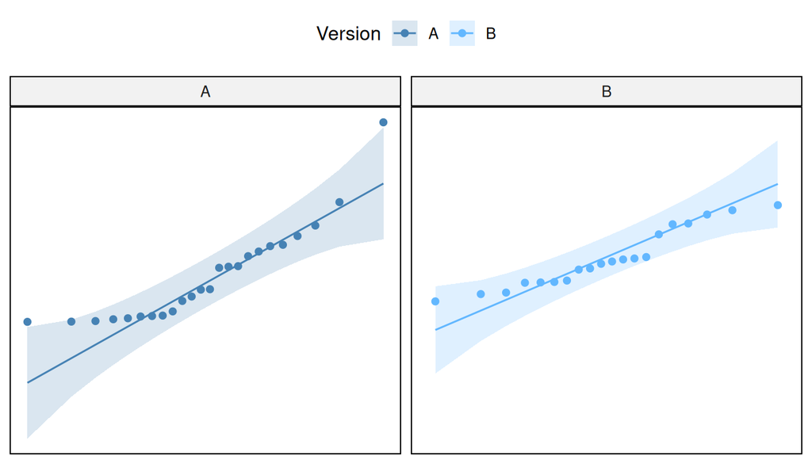

```r
# 1. Crear el data frame directamente en formato largo
# Esto soluciona el problema de los tamaños desiguales (24 y 20)
df_A <- data.frame(Version = "A", Tiempo = muestra_A_P1)
df_B <- data.frame(Version = "B", Tiempo = muestra_B_P1)

# Unir ambos grupos uno debajo del otro
datos_largos_P1 <- rbind(df_A, df_B) %>%
  mutate(Version = factor(Version))

# 2. Generar los gráficos Q-Q con la configuración solicitada
# Nota: Usamos conf.int = TRUE para mostrar la banda de confianza del 0.05
g1 <- ggqqplot(datos_largos_P1,
               x = "Tiempo",
               facet.by = "Version", # Esta opción de ggpubr es más directa
               color = "Version",
               conf.int = TRUE,      # Crucial para determinar normalidad [cite: 918]
               palette = c("steelblue", "steelblue1"))

# Ajustes estéticos solicitados
g1 <- g1 +
  rremove("x.ticks") + rremove("x.text") +
  rremove("y.ticks") + rremove("y.text") +
  rremove("axis.title")

print(g1)
```

El gráfico para la muestra de tiempos A sugiere que los datos no siguen una distribución normal, debido a un par de puntos alejados del área de confianza. Respecto a la muestra B sugiere que sí existe normalidad para la distribución.

```r
# Prueba de normalidad
shapiro_A <- shapiro.test(muestra_A_P1)
shapiro_B <- shapiro.test(muestra_B_P1)

print(shapiro_A)
```

```
##
##  Shapiro-Wilk normality test
##
## data:  muestra_A_P1
## W = 0.8452, p-value = 0.001783
```

```r
print(shapiro_B)
```

```
##
##  Shapiro-Wilk normality test
##
## data:  muestra_B_P1
## W = 0.92309, p-value = 0.1137
```

Las pruebas Shapiro-Wilk confirman la información que entregan los QQ-plot. Con un nivel de confianza de 95% se rechaza la hipótesis nula de normalidad para la muestra A y para la muestra B no es posible rechazar (existe normalidad).

## Selección de la prueba

Como no es posible aplicar la prueba paramétrica de t student para una o dos muestras, haremos uso de la alternativa no paramétrica: Wilcoxon-Mann-Whitney, prueba que requiere las siguientes condiciones:

1. Las observaciones de ambas muestras son independientes.
2. La escala de medición empleada debe ser a lo menos ordinal, de modo que tenga sentido hablar de relaciones de orden (“igual que”, “mayor que”, “menor o igual que”).

## Formulación de Hipótesis

Las hipótesis a utilizar son:

$H_0$: No hay diferencias significativas en el tiempo de ejecución entre las versiones A y B del algoritmo cuando las instancias tienen 70 o más nodos.

$H_a$: Hay diferencias significativas en el tiempo de ejecución entre las versiones A y B del algoritmo cuando las instancias tienen 70 o más nodos.

## Condiciones

La primera condición de la prueba (observaciones de ambas muestras independientes) ya ha sido probada, basándose en la aleatoriedad de las muestras realizadas. La segunda habla acerca de la escala de medición empleada para la variable dependiente, que en este caso corresponde al tiempo de ejecución de las versiones del algoritmo, el cual presenta una escala de razón, por lo que sí se cumple.

## Prueba estadística

En este caso, como tenemos muestras “grandes” (mayores a 5 observaciones) utilizamos la función wilcox.test() para aplicar la prueba:

```r
# Documentación de la lectura
# x, y: los vectores de las muestras
# paired = FALSE: indica que las muestras son independientes
# alternative = "two.sided": busca cualquier diferencia (bilateral)
# conf.level = 0.95: nivel de confianza definido (alfa = 0.05)
# mu = se omite, por lo que la diferencia de medias es cero

resultado_wilcox <- wilcox.test(x = muestra_A_P1,
                                y = muestra_B_P1,
                                paired = FALSE,
                                alternative = "two.sided",
                                conf.level = 0.95)

print(resultado_wilcox)
```

```
##
##  Wilcoxon rank sum exact test
##
## data:  muestra_A_P1 and muestra_B_P1
## W = 160, p-value = 0.06047
## alternative hypothesis: true location shift is not equal to 0
```

## Conclusión

Se obtuvieron dos muestras aleatorias de tamaño $n_A=24$ y $n_B=20$ para los tiempos de ejecución de las versiones A y B del algoritmo genético. Se ha demostrado que el uso de la prueba paramétrica t de student para dos muestras independientes no puede aplicarse, debido a que tenemos evidencia para afirmar que no se cumple la normalidad en una de ellas. Luego, se decidió utilizar su alternativa no paramétrica: La prueba de Wilcoxon-Mann-Whitney. Continuamos con la definición de las hipótesis, la comprobación de condiciones (que salió exitosa) y la aplicación de la prueba.

El resultado obtenido es un $p_{value}=0.06047$ el cual supera al nivel de significancia $\alpha=0.05$, por lo que no existe evidencia suficiente para rechazar la hipótesis nula. En consecuencia, con un 95% de confianza, no es posible afirmar que haya diferencias significativas entre la distribución de los tiempos de ejecución para las versiones A y B del algoritmo, sugiriendo que los datos no respaldan la intuición de la memorista.

Nota: Todas las condiciones de las pruebas fueron extraídas del libro Jara y Köhler (s. f.).

# Problema 2

La memorista también sospecha que, al comparar las mismas instancias de prueba con iguales características, las mejores soluciones encontradas por las versiones B y C tienen rendimientos distintos. ¿Estará en lo cierto? Para responder, filtren los datos para tener las instancias con 70 o más nodos y seleccionen las columnas con el mejor rendimiento de las versiones B y C en formato ancho. Usando como semilla el valor 71, obtengan una muestra aleatoria de 24 instancias. Realicen un análisis estadístico pertinente (enunciar hipótesis, revisar condiciones, seleccionar pruebas ómnibus y post-hoc según corresponda) para responder la pregunta planteada, utilizando pruebas no paramétricas de ser necesario.

# Respuesta 2

```r
library(dplyr)

# Fijar semilla para reproducibilidad
set.seed(71)

# Filtrar por nodos, seleccionar columnas de rendimiento y obtener muestra
datos_filtrados_pregunta_2 <- datos_algoritmo %>%
  filter(n.nodos >= 70) %>%
  select(mejor.B, mejor.C) %>%
  sample_n(24)

# Mostrar tabla completa de la muestra
datos_filtrados_pregunta_2 %>%
  mutate(Instancia = row_number()) %>%
  relocate(Instancia) %>%
  kbl(caption = "Muestra Aleatoria de Mejores Rendimientos (n=24 instancias, ≥70 nodos)",
      booktabs = TRUE,
      align = "c",
      col.names = c("Instancia", "Versión B", "Versión C")) %>%
  kable_styling(bootstrap_options = c("striped", "hover", "condensed"),
                full_width = F,
                position = "center") %>%
  add_header_above(c(" " = 1, "Mejor Rendimiento (%)" = 2))
```

Muestra Aleatoria de Mejores Rendimientos (n=24 instancias, ≥70 nodos)

| Instancia | Mejor Rendimiento (%) Versión B | Mejor Rendimiento (%) Versión C |
| --- | --- | --- |
| 1 | 95.00 | 98.21 |
| 2 | 95.60 | 98.48 |
| 3 | 98.36 | 98.26 |
| 4 | 94.60 | 96.63 |
| 5 | 88.75 | 90.74 |
| 6 | 97.38 | 97.43 |
| 7 | 88.46 | 97.49 |
| 8 | 92.36 | 95.19 |
| 9 | 97.57 | 97.93 |
| 10 | 97.15 | 96.14 |
| 11 | 98.84 | 98.42 |
| 12 | 91.48 | 91.47 |
| 13 | 85.99 | 95.33 |
| 14 | 96.93 | 97.35 |
| 15 | 95.59 | 95.42 |
| 16 | 94.93 | 97.12 |
| 17 | 94.17 | 95.88 |
| 18 | 96.90 | 99.44 |
| 19 | 95.10 | 97.13 |
| 20 | 95.33 | 95.48 |
| 21 | 93.13 | 97.03 |
| 22 | 97.46 | 98.62 |
| 23 | 97.92 | 97.36 |
| 24 | 95.97 | 95.91 |

## Condiciones paramétricas

En este problema se comparan los mejores rendimientos de las versiones B y C sobre las mismas instancias de prueba. Por lo que se debe aplicar una prueba de muestras correlacionadas.La prueba paramétrica correspondiente sería una prueba t de Student para muestras pareadas, cuyas condiciones son:

1. Los pares de observaciones son independientes entre sí.
2. Las diferencias entre observaciones apareadas siguen una distribución cercana a la normal.

La primera condición se cumple: las 24 instancias fueron seleccionadas aleatoriamente, y cada instancia es independiente de las demás. Para la segunda condición, debemos verificar la normalidad de las diferencias:

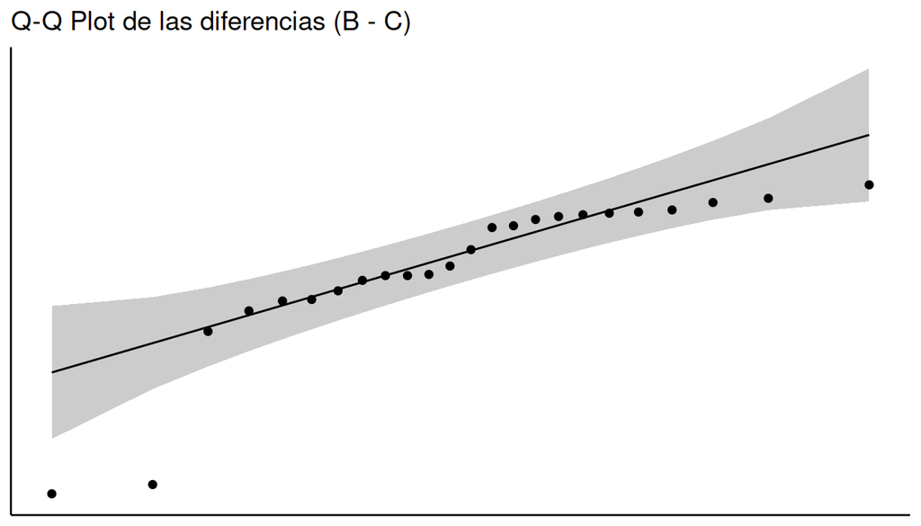

```r
#Calcular las diferencias pareadas
diferencias_P2 <- datos_filtrados_pregunta_2$mejor.B - datos_filtrados_pregunta_2$mejor.C

ggqqplot(diferencias_P2, title = "Q-Q Plot de las diferencias (B - C)") + rremove("x.ticks") + rremove("x.text") + rremove("y.ticks") + rremove("y.text") + rremove("axis.title")
```

Se observan la mayoría de las observaciones dentro de nuestro rango de confianza, pero tenemos outliers. Para confirmar esto aplicamos la prueba de normalidad de Shapiro-Wilk:

```r
shapiro_dif_P2 <- shapiro.test(diferencias_P2)
print(shapiro_dif_P2)
```

```
##
##  Shapiro-Wilk normality test
##
## data:  diferencias_P2
## W = 0.78496, p-value = 0.000169
```

Obtenemos un $p-value = 0.0002$, siendo menor que $0.05$ se rechaza la normalidad. Se debe continuar con una alternativa no paramétrica.

## Selección de la prueba

Dado que se comparan dos muestras correlacionadas, se utiliza la prueba de rangos con signo de Wilcoxon, que es la alternativa no paramétrica para muestras pareadas.

Las condiciones para esta prueba son:

1. Los pares de observaciones son independientes entre sí.
2. La escala de medición empleada para ambas muestras debe ser a lo menos ordinal.

## Formulación de Hipótesis

- $H_0$: No hay diferencias en el rendimiento de las mejores soluciones encontradas por las versiones B y C del algoritmo cuando se comparan sobre las mismas instancias con 70 o más nodos.
- $H_A$: Hay diferencias en el rendimiento de las mejores soluciones encontradas por las versiones B y C del algoritmo cuando se comparan sobre las mismas instancias con 70 o más nodos.

## Condiciones

La primera condición ya vimos que se cumple, ya que las 24 instancias fueron seleccionadas de manera aleatoria, y cada par de observaciones (B, C) corresponde a una instancia distinta e independiente del resto.

La segunda condición también se cumple: el rendimiento medido en porcentaje es numérico y ordinal.

## Prueba estadística

Ya verificadas la elección de la prueba, y sus condiciones, procedemos a realizar la prueba.

```r
# Prueba de rangos con signo de Wilcoxon para muestras pareadas
resultado_wilcox_P2 <- wilcox.test(datos_filtrados_pregunta_2$mejor.B,
                                    datos_filtrados_pregunta_2$mejor.C,
                                    paired = TRUE,
                                    alternative = "two.sided",
                                    conf.level = 0.95)

print(resultado_wilcox_P2)
```

```
##
##  Wilcoxon signed rank exact test
##
## data:  datos_filtrados_pregunta_2$mejor.B and datos_filtrados_pregunta_2$mejor.C
## V = 44, p-value = 0.001555
## alternative hypothesis: true location shift is not equal to 0
```

## Conclusión

Se obtuvo un $p-valor=0.001555$ y un estadístico $V=44$. Aplicada la prueba con un $\alpha=0.05$, vemos que $p$ obtenido es menor al nivel de significación, por lo que existe evidencia suficiente para rechazar la hipótesis nula en favor de la alternativa. Esto quiere decir que existen diferencias significativas entre los rendimientos de ambas versiones.

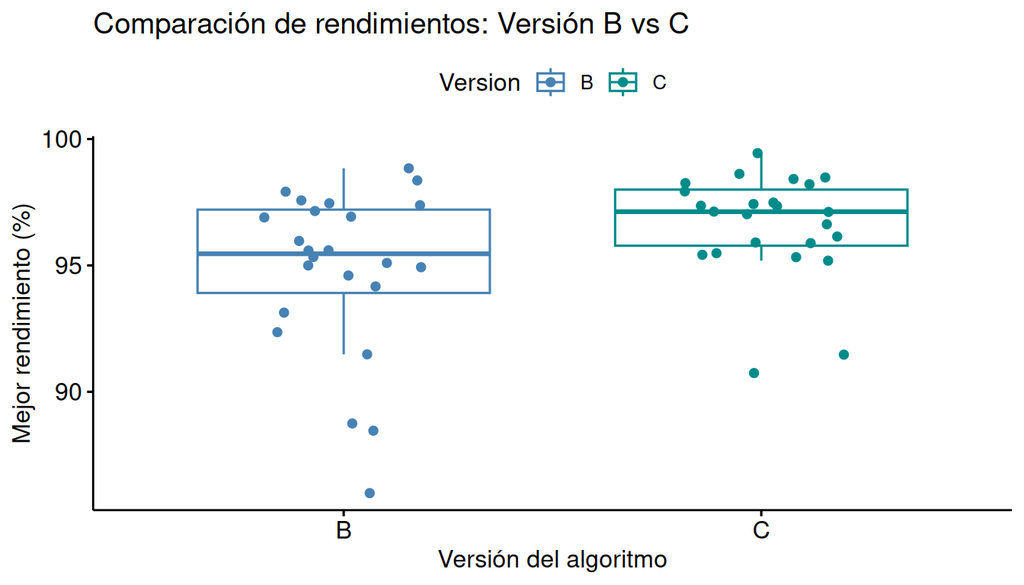

```r
# Boxplot comparativo de rendimientos B vs C
datos_largo_P2 <- datos_filtrados_pregunta_2 %>%
  mutate(Instancia = row_number()) %>%
  pivot_longer(cols = c(mejor.B, mejor.C),
               names_to = "Version",
               names_prefix = "mejor.",
               values_to = "Rendimiento")

ggboxplot(datos_largo_P2,
          x = "Version", y = "Rendimiento",
          color = "Version",
          palette = c("steelblue", "darkcyan"),
          add = "jitter",
          title = "Comparación de rendimientos: Versión B vs C",
          xlab = "Versión del algoritmo",
          ylab = "Mejor rendimiento (%)")
```

Validado que existe una diferencia significativa entre ambas versiones, con la ayuda del Boxplot podemos concluir que el algoritmo de la versión C tiene un mejor rendimiento que el algoritmo de la versión B.

# Problema 3

La memorista además cree que hay diferencias significativas en el tiempo de ejecución entre las diferentes versiones del algoritmo cuando las instancias de prueba tienen 50 o más nodos. ¿Los datos respaldan la intuición de la memorista? Para responder, filtren los datos para tener las instancias con 50 o más nodos y seleccionen las columnas con los tiempos de ejecución registrados (en formato ancho). Usando como semilla el valor 31, obtengan muestras aleatorias independientes de 14, 12 y 13 tiempos registrados por las versiones A, B y C, respectivamente. Realicen un análisis estadístico pertinente (enunciar hipótesis, revisar condiciones, seleccionar pruebas ómnibus y post-hoc según corresponda) para responder la pregunta planteada, utilizando pruebas no paramétricas de ser necesario.

# Respuesta 3

```r
library(dplyr)

# Fijar semilla para asegurar la reproducibilidad
set.seed(31)

# Filtrar instancias con 50 o más nodos y seleccionar columnas de tiempo
datos_filtrados_pregunta_3 <- datos_algoritmo %>%
  filter(n.nodos >= 50) %>%
  select(tiempo.A, tiempo.B, tiempo.C)

# Obtener muestras aleatorias independientes (tamaños: 14, 12 y 13)
muestra_A_P3 <- sample(datos_filtrados_pregunta_3$tiempo.A, 14)
muestra_B_P3 <- sample(datos_filtrados_pregunta_3$tiempo.B, 12)
muestra_C_P3 <- sample(datos_filtrados_pregunta_3$tiempo.C, 13)
```

Mostrar las muestras obtenidas:

```r
library(knitr)
library(kableExtra)

# Determinar el tamaño máximo para nivelar las columnas
max_n <- max(length(muestra_A_P3), length(muestra_B_P3), length(muestra_C_P3))

# Crear un data frame unificado rellenando con NA donde falten datos
tabla_muestras_P3 <- data.frame(
  Algoritmo_A = c(muestra_A_P3, rep(NA, max_n - length(muestra_A_P3))),
  Algoritmo_B = c(muestra_B_P3, rep(NA, max_n - length(muestra_B_P3))),
  Algoritmo_C = c(muestra_C_P3, rep(NA, max_n - length(muestra_C_P3)))
)

# Generar la tabla
tabla_muestras_P3 %>%
  kbl(caption = "Muestras Aleatorias Independientes de Tiempos de Ejecución (n=14, 12, 13)",
      booktabs = TRUE,
      align = "c",
      col.names = c("Versión A", "Versión B", "Versión C")) %>%
  kable_styling(bootstrap_options = c("striped", "hover", "condensed"),
                full_width = F,
                position = "center") %>%
  add_header_above(c("Tiempos Registrados (ms)" = 3))
```

Muestras Aleatorias Independientes de Tiempos de Ejecución (n=14, 12, 13)

| Tiempos Registrados (ms) Versión A | Tiempos Registrados (ms) Versión B | Tiempos Registrados (ms) Versión C |
| --- | --- | --- |
| 398278 | 3595410 | 2133500 |
| 694845 | 2453589 | 1676428 |
| 3307370 | 421852 | 451458 |
| 318794 | 1174722 | 1561804 |
| 453516 | 2249226 | 592528 |
| 205476 | 2660914 | 1484462 |
| 717980 | 1046482 | 1255338 |
| 131095 | 398448 | 337776 |
| 2176449 | 1366115 | 484734 |
| 4119227 | 3235980 | 1437173 |
| 343080 | 1840875 | 281613 |
| 2423249 | 1791186 | 1906000 |
| 1307970 | NA | 1869008 |
| 2571876 | NA | NA |

## Condiciones paramétricas

La prueba paramétrica apropiada para este problema sería un ANOVA de una vía para muestras independientes, ya que se busca comparar los tiempos de ejecución entre tres versiones distintas del algoritmo. Para su aplicación se requiere que:

1. La variable dependiente tenga propiedades de una escala de intervalos iguales.
2. Las muestras sean independientes entre sí.
3. Las observaciones provengan de poblaciones con distribución cercana a la normal.
4. Las varianzas de las poblaciones sean similares.

En este caso, la variable dependiente corresponde al tiempo de ejecución en milisegundos, por lo que se mide en una escala de razón. Además, el enunciado solicita obtener muestras aleatorias independientes para las versiones A, B y C, por lo que la independencia se cumple por diseño. Sin embargo, todavía se debe revisar si los tiempos de ejecución provienen de distribuciones aproximadamente normales y si las varianzas pueden considerarse similares.

A continuación, se comprueba visualmente la normalidad mediante gráficos Q-Q y luego se formaliza esta revisión mediante la prueba Shapiro-Wilk, usando un nivel de significación de 0,05:

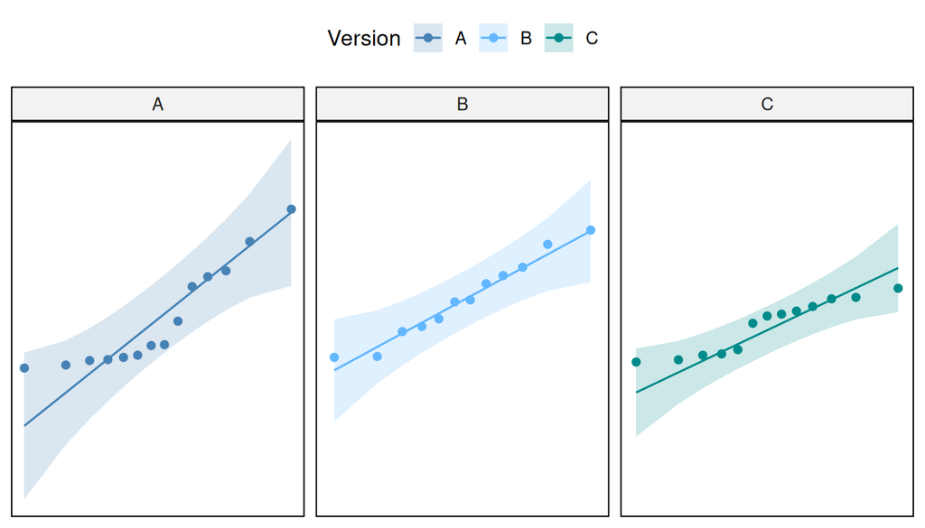

```r
library(ggpubr)

datos_largos_P3 <- data.frame(
  Version = factor(c(
    rep("A", length(muestra_A_P3)),
    rep("B", length(muestra_B_P3)),
    rep("C", length(muestra_C_P3))
  )),
  Tiempo = c(muestra_A_P3, muestra_B_P3, muestra_C_P3)
)

g_p3 <- ggqqplot(datos_largos_P3,
                 x = "Tiempo",
                 facet.by = "Version",
                 color = "Version",
                 conf.int = TRUE,
                 palette = c("steelblue", "steelblue1", "darkcyan"))

g_p3 <- g_p3 +
  rremove("x.ticks") + rremove("x.text") +
  rremove("y.ticks") + rremove("y.text") +
  rremove("axis.title")

print(g_p3)
```

Los gráficos Q-Q permiten comparar los cuantiles observados de cada muestra con los cuantiles esperados bajo una distribución normal. Si los datos fueran aproximadamente normales, los puntos deberían ubicarse cerca de la línea recta y dentro de la banda de confianza. En este caso se observan desviaciones respecto de la línea en al menos una de las versiones, lo que sugiere que no todas las muestras cumplen razonablemente la condición de normalidad.

```r
normalidad_p3 <- datos_largos_P3 %>%
  group_by(Version) %>%
  summarise(
    W = as.numeric(shapiro.test(Tiempo)$statistic),
    p_valor = shapiro.test(Tiempo)$p.value,
    .groups = "drop"
  )

normalidad_p3 %>%
  kbl(digits = 4,
      caption = "Prueba de Shapiro-Wilk para los tiempos de ejecución") %>%
  kable_styling(bootstrap_options = c("striped", "hover", "condensed"),
                full_width = FALSE)
```

Prueba de Shapiro-Wilk para los tiempos de ejecución

| Version | W | p_valor |
| --- | --- | --- |
| A | 0.8454 | 0.0193 |
| B | 0.9651 | 0.8540 |
| C | 0.8881 | 0.0918 |

La prueba de Shapiro-Wilk confirma lo observado en los gráficos Q-Q. Con un nivel de significación $\alpha = 0,05$, al menos una de las muestras presenta evidencia suficiente para rechazar la hipótesis nula de normalidad. Por lo tanto, no se cumple una de las condiciones necesarias para aplicar válidamente un ANOVA de una vía paramétrico.

Como complemento, se revisa la homogeneidad de varianzas mediante la prueba de Levene:

```r
datos_ez_P3 <- datos_largos_P3 %>%
  mutate(Instancia_ID = factor(1:n()))

# Realizar el ANOVA usando ezANOVA()
prueba_ez_P3 <- ezANOVA(
  data = datos_ez_P3,
  dv = Tiempo,             # Variable Dependiente (Tiempo)
  wid = Instancia_ID,      # Identificador único de la observación
  between = Version,       # Factor entre-sujetos
  return_aov = TRUE,
  detailed = TRUE
)

# Mostrar resultados extrayendo la prueba de Levene que es la que nos interesa
print(prueba_ez_P3$`Levene's Test for Homogeneity of Variance`)
```

```
##   DFn DFd          SSn          SSd        F        p p<.05
## 1   2  36 1.370756e+12 1.993104e+13 1.237949 0.302028
```

La prueba de Levene no entrega evidencia suficiente para rechazar la hipótesis nula de igualdad de varianzas entre las versiones, arrojando un $p-valor=0.30$. Sin embargo, aunque esta condición no presenta problemas importantes, el incumplimiento de normalidad ya es suficiente para preferir una prueba no paramétrica.

## Selección de la prueba

Como no se cumplen todas las condiciones para aplicar un ANOVA de una vía, corresponde utilizar una alternativa no paramétrica. Según la lectura del capítulo 11, para comparar más de dos muestras independientes se utiliza la prueba de Kruskal-Wallis.

Esta prueba funciona como una prueba ómnibus: permite determinar si existe evidencia de diferencias entre las distribuciones de al menos dos grupos, pero no indica por sí sola entre qué versiones se encuentran esas diferencias. Por eso, solo si la prueba resulta significativa corresponde aplicar un análisis post-hoc con pruebas de Wilcoxon-Mann-Whitney para comparaciones entre pares, ajustando los valores p por comparaciones múltiples.

## Formulación de Hipótesis

- $H_0$: No hay diferencias significativas en la localización de los tiempos de ejecución entre las versiones A, B y C del algoritmo cuando las instancias tienen 50 o más nodos.
- $H_A$: Al menos una versión del algoritmo presenta una localización de tiempos de ejecución distinta a la de otra versión cuando las instancias tienen 50 o más nodos.

## Condiciones

Las condiciones de la prueba de Kruskal-Wallis son:

1. La escala de la variable dependiente debe ser, a lo menos, ordinal.
2. Las observaciones deben ser independientes entre sí.
3. La variable independiente debe tener al menos dos niveles.

Estas condiciones se cumplen en este caso. El tiempo de ejecución en milisegundos es una variable numérica de razón, las muestras fueron obtenidas de forma aleatoria e independiente para cada versión, y la variable independiente corresponde a la versión del algoritmo, con tres niveles: A, B y C.

## Prueba estadística

```r
prueba_kruskal_p3 <- kruskal.test(Tiempo ~ Version, data = datos_largos_P3)
prueba_kruskal_p3
```

```
##
##  Kruskal-Wallis rank sum test
##
## data:  Tiempo by Version
## Kruskal-Wallis chi-squared = 2.7011, df = 2, p-value = 0.2591
```

## Conclusión

Con un nivel de significación $\alpha = 0,05$, la prueba de Kruskal-Wallis entrega un p-valor aproximado de $0,259$, el cual es mayor que $0,05$. Por lo tanto, no existe evidencia suficiente para rechazar la hipótesis nula.

En consecuencia, a partir de las muestras analizadas no es posible afirmar que existan diferencias significativas en el tiempo de ejecución entre las versiones A, B y C del algoritmo cuando las instancias tienen 50 o más nodos. Así, los datos no respaldan la intuición de la memorista. Además, como la prueba ómnibus no resultó significativa, no corresponde realizar un análisis post-hoc entre pares de versiones.

# Problema 4

La memorista también intuye que, al comparar las mismas instancias de prueba con iguales características, las mejores soluciones encontradas por las diferentes versiones del algoritmo tienen rendimientos distintos. ¿Estará en lo cierto? Para responder, filtren los datos para tener las instancias con 50 o más nodos y seleccionen las columnas con los mejores rendimientos registrados. Usando como semilla el valor 31, obtengan una muestra aleatoria de 22 instancias. Realicen un análisis estadístico pertinente (enunciar hipótesis, revisar condiciones, seleccionar pruebas ómnibus y post-hoc según corresponda) para responder la pregunta planteada, utilizando pruebas no paramétricas de ser necesario.

# Respuesta 4

```r
library(dplyr)

# Fijar semilla para asegurar la reproducibilidad
set.seed(31)

# Filtrar instancias y seleccionar columnas de mejor rendimiento
datos_filtrados_pregunta_4 <- datos_algoritmo %>%
  filter(n.nodos >= 50) %>%
  select(mejor.A, mejor.B, mejor.C)

# Obtener muestra aleatoria de 22 instancias
muestra_rendimiento <- datos_filtrados_pregunta_4 %>%
  slice_sample(n = 22)
```

Mostrar los datos de la muestra:

```r
library(knitr)
library(kableExtra)

muestra_rendimiento %>%
  kbl(caption = "Muestra Aleatoria de Rendimientos (n=22 instancias)",
      booktabs = TRUE,
      align = "c") %>%
  kable_styling(bootstrap_options = c("striped", "hover"),
                full_width = F)
```

Muestra Aleatoria de Rendimientos (n=22 instancias)

| mejor.A | mejor.B | mejor.C |
| --- | --- | --- |
| 99.25 | 98.60 | 97.58 |
| 98.80 | 95.24 | 99.46 |
| 95.84 | 95.10 | 97.13 |
| 98.58 | 98.01 | 96.20 |
| 97.60 | 95.10 | 97.73 |
| 99.06 | 98.02 | 98.26 |
| 99.02 | 97.16 | 97.30 |
| 99.19 | 97.79 | 98.43 |
| 98.65 | 97.18 | 93.18 |
| 95.06 | 93.01 | 95.59 |
| 99.42 | 96.36 | 98.95 |
| 96.60 | 94.17 | 95.88 |
| 97.59 | 94.40 | 97.35 |
| 99.87 | 95.59 | 95.42 |
| 93.40 | 92.70 | 97.04 |
| 97.56 | 92.95 | 97.71 |
| 99.78 | 97.70 | 99.88 |
| 98.57 | 97.50 | 95.63 |
| 98.37 | 93.58 | 98.21 |
| 95.09 | 96.32 | 94.63 |
| 97.73 | 99.84 | 89.20 |
| 99.19 | 99.15 | 98.04 |

## Condiciones paramétricas

La prueba paramétrica de referencia para esta pregunta sería un ANOVA de una vía para muestras correlacionadas, ya que se comparan los mejores rendimientos obtenidos por las versiones A, B y C del algoritmo. En este diseño, cada fila de la muestra corresponde a una misma instancia evaluada por las tres versiones, por lo que las mediciones no deben tratarse como independientes entre versiones.

Es importante notar que el hecho de tener tres columnas con el mismo tamaño no basta por sí solo para hablar de muestras correlacionadas. Lo decisivo es que las tres mediciones de rendimiento provienen de la misma instancia, compartiendo sus características propias, como número de nodos, número de aristas y dificultad del problema.

Para aplicar válidamente un ANOVA de una vía para muestras correlacionadas, se deben cumplir las siguientes condiciones:

1. La variable dependiente debe tener propiedades de una escala de intervalos iguales.
2. Las observaciones o casos deben ser independientes entre sí.
3. Las poblaciones de origen deben seguir una distribución aproximadamente normal.
4. La matriz de varianzas-covarianzas debe cumplir la condición de esfericidad.

En este caso, la variable dependiente corresponde al mejor rendimiento registrado, medido como porcentaje de cercanía a la solución óptima. Esta variable es numérica y puede ordenarse e interpretarse en términos de magnitud. Además, las 22 instancias fueron seleccionadas como una muestra aleatoria, por lo que se puede asumir independencia entre instancias. Sin embargo, como las versiones A, B y C se evalúan sobre las mismas instancias, corresponde trabajar el problema como un diseño de muestras correlacionadas y revisar las condiciones de normalidad y esfericidad antes de aplicar un procedimiento paramétrico.

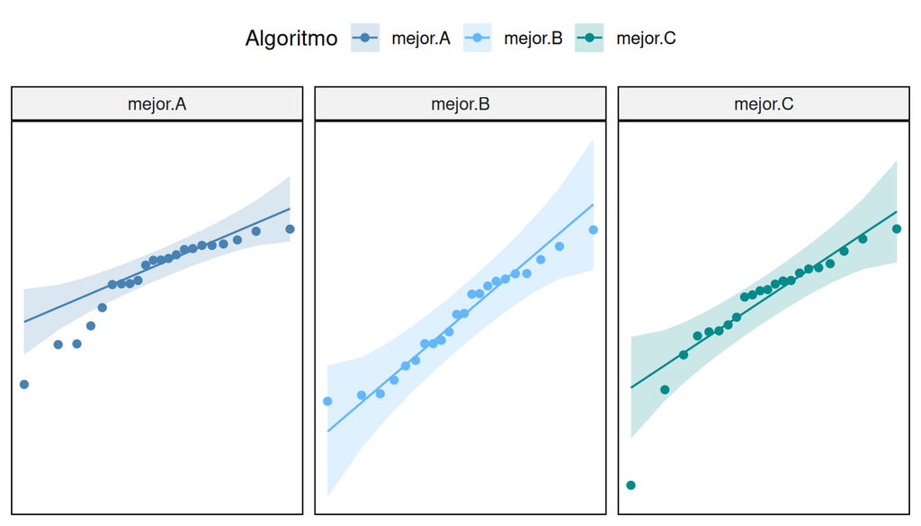

```r
# Transformar a formato largo para verificar normalidad
muestra_larga_p4 <- muestra_rendimiento %>%
  mutate(instancia = row_number()) %>%
  pivot_longer(cols = starts_with("mejor"),
               names_to = "Algoritmo",
               values_to = "Rendimiento")

# Gráficos Q-Q por versión
ggqqplot(muestra_larga_p4,
         x = "Rendimiento",
         facet.by = "Algoritmo",
         color = "Algoritmo",
         conf.int = TRUE,
         palette = c("steelblue", "steelblue1", "darkcyan")) +
  rremove("x.ticks") + rremove("x.text") +
  rremove("y.ticks") + rremove("y.text") +
  rremove("axis.title")
```

El gráfico Q-Q falla en mostrar normalidad para la versión A y C, habiendo observaciones fuera del rango aceptable. Confirmamos esto con una prueba de Shapiro-Wilk:

```r
# Pruebas de normalidad de Shapiro-Wilk por versión
normalidad_p4 <- muestra_larga_p4 %>%
  group_by(Algoritmo) %>%
  summarise(
    W = as.numeric(shapiro.test(Rendimiento)$statistic),
    p_valor = shapiro.test(Rendimiento)$p.value,
    .groups = "drop"
  )

normalidad_p4 %>%
  kbl(digits = 4,
      caption = "Prueba de Shapiro-Wilk para los rendimientos por versión") %>%
  kable_styling(bootstrap_options = c("striped", "hover", "condensed"),
                full_width = FALSE)
```

Prueba de Shapiro-Wilk para los rendimientos por versión

| Algoritmo | W | p_valor |
| --- | --- | --- |
| mejor.A | 0.8676 | 0.0071 |
| mejor.B | 0.9579 | 0.4483 |
| mejor.C | 0.8641 | 0.0061 |

La prueba de Shapiro-Wilk arroja los siguientes resultados: - mejor.A: $p=0.0071$ - mejor.B: $p=0.4483$ - mejor.C: $p=0.0061$

Confirmando lo observado en el gráfico Q-Q, se rechaza la hipótesis nula de normalidad para los algoritmos A y C.

## Selección de la prueba

Como las versiones A, B y C se comparan usando las mismas instancias, las muestras son correlacionadas. Por eso, si se cumplieran las condiciones paramétricas, correspondería aplicar un ANOVA de una vía para muestras correlacionadas.

Sin embargo, si alguna condición importante no se cumple, especialmente normalidad o esfericidad, la alternativa no paramétrica adecuada es la prueba de Friedman. Esta prueba permite comparar tres o más muestras correlacionadas y funciona como prueba ómnibus: indica si hay evidencia de diferencias entre las versiones, pero no señala directamente entre qué pares ocurren.

Si Friedman resulta significativa, el análisis debería continuar con comparaciones post-hoc mediante pruebas de rangos con signo de Wilcoxon para muestras pareadas, usando una corrección por comparaciones múltiples, como Holm.

## Formulación de Hipótesis

Como no se cumplen las condiciones necesarias para aplicar el ANOVA de medidas repetidas, se utiliza la alternativa no paramétrica de Friedman, las hipótesis se adaptan a una comparación de rangos o localización:

- $H_0$: Las versiones A, B y C presentan rendimientos similares cuando se comparan sobre las mismas instancias de prueba.
- $H_A$: Al menos una versión del algoritmo presenta rendimientos distintos respecto de otra versión.

## Condiciones

Recordemos las condiciones requeridas para aplicar la prueba de Friedman que son menos restrictivas que la prueba ANOVA:

1. La escala de la variable dependiente debe ser, a lo menos, ordinal.
2. Las observaciones son una muestra aleatoria e independiente de la población.
3. La variable independiente debe ser categórica y tener a lo menos tres niveles.

La variable dependiente estudiada corresponde a un porcentaje que representa la cercanía a la solución óptima. Este valor depende de esa solución óptima reportada y es relativo para cada instancia de la muestra. Por lo tanto, para una misma instancia podemos decir que la variable dependiente es ordinal, ya que admite comparaciones de tipo igual que, menor que, mayor o igual que, entre otras.

Respecto a las observaciones, se seleccionó la función sample_n en un principio, pero, siguiendo las recomendaciones de la documentación de R, se cambió por slice_sample() que es una versión más optimizada. El uso de funciones dedicadas nos asegura que las observaciones de cada muestra sean aleatorias y no dependan de la población.

Por último, la variable independiente involucrada corresponde a las versiones del algoritmo. Es una variable categórica, ya que permite clasificar los datos de acuerdo a sus 3 niveles fijos (A, B y C).

## Prueba estadística

A continuación aplicamos la prueba de Friedman no paramétrica con un nivel de significancia de 0.05:

```r
# Cargar librerías necesarias
library(tidyr)
library(dplyr)

# Aplicar la prueba de Friedman
# Rendimiento (VD) ~ Algoritmo (VI) | instancia (ID_Caso)
resultado_friedman <- friedman.test(Rendimiento ~ Algoritmo | instancia,
                                    data = muestra_larga_p4)

# Mostrar resultados
print(resultado_friedman)
```

```
##
##  Friedman rank sum test
##
## data:  Rendimiento and Algoritmo and instancia
## Friedman chi-squared = 14.273, df = 2, p-value = 0.0007956
```

Obtenemos un $p-value=0.0007956$ y un estadístico chi-cuadrado = $14.273$

Como el valor p está por debajo del nivel de significancia, se requiere la aplicación de procedimientos post-hoc. En este caso, utilizamos la corrección de Holm mediante la función pairwise.wilcox.test():

```r
library(tidyr)
library(dplyr)
library(broom)
library(knitr)

# Definir nivel de significancia
alfa <- 0.05

# Efectuar procedimiento post-hoc de Holm
  # Realizamos comparaciones por pares con corrección de Holm
post_hoc <- pairwise.wilcox.test(muestra_larga_p4$Rendimiento,
                                 muestra_larga_p4$Algoritmo,
                                 p.adjust.method = "holm",
                                 paired = TRUE, exact = FALSE)

  # Organización de resultados
  post_hoc_tidy <- tidy(post_hoc) |>
    rename(Grupo1 = group2, Grupo2 = group1) |>
    arrange(Grupo1) |>
    relocate(Grupo1)

  cat("Resultados del análisis post-hoc (Corrección de Holm):\n")
```

```
## Resultados del análisis post-hoc (Corrección de Holm):
```

```r
  cat(paste0("  ", kable(post_hoc_tidy, digits = 3, format = "simple")), sep = "\n")
```

```
##   Grupo1    Grupo2     p.value
##   --------  --------  --------
##   mejor.A   mejor.B      0.002
##   mejor.A   mejor.C      0.046
##   mejor.B   mejor.C      0.119
```

La prueba apareada de wilcox con corrección de Holm nos arroja los siguientes resultados: - Par (A, B): $p=0.002$ - Par (A, C): $p=0.046$ - Par (B, C): $p=0.119$

## Conclusión

Por lo tanto, rechazada la hipótesis nula de la prueba ómnibus se procede al análisis post-hoc, identificando diferencias significativas entre el par (A, B) y el par (A, C), no existen diferencias significativas entre las versiones B y C. Para comprender bien las diferencias existentes realizamos un boxplot:

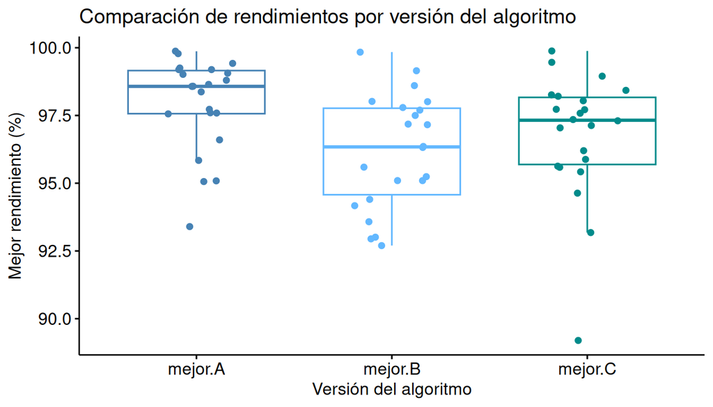

```r
ggboxplot(muestra_larga_p4,
          x = "Algoritmo", y = "Rendimiento",
          color = "Algoritmo",
          palette = c("steelblue", "steelblue1", "darkcyan"),
          add = "jitter",
          title = "Comparación de rendimientos por versión del algoritmo",
          xlab = "Versión del algoritmo",
          ylab = "Mejor rendimiento (%)") +
  theme(legend.position = "none")
```

De esta forma, visualmente se confirma que la diferencia que corresponde a la versión A es de superioridad. Teniendo esta versión un mejor rendimiento tanto sobre la versión B como la versión C. Por lo tanto, los datos respaldan la intuición de la memorista: los rendimientos de las versiones no son iguales.

# Referencias

Jara, J. L., & Köhler, J. (s. f.). Inferencia y modelos estadísticos [Perusall].